# DATA 624_Exercises_HA 7.1-7.3

Jeremy O’Brien

September 23, 2019

```r
if (!require('fpp2')) (install.packages('fpp2'))
if (!require('forecast')) (install.packages('forecast'))
if (!require('dplyr')) (install.packages('dplyr'))
if (!require('tidyr')) (install.packages('tidyr'))
if (!require('magrittr')) (install.packages('magrittr'))
if (!require('scales')) (install.packages('scales'))
```

### Exercise 7.1

#### Consider the `pigs` series - the number of pigs slaughtered in Victoria each month.

#### (a) Use the `ses()` function in R to find the optimal values of $\alpha$ and $\ell_{0}$, and generate a forecast for the next four months.

```r
# Fit SES for 4 periods ahead
pigs_fc <- pigs %>%
  ses(h = 4)

# Point forecast, alpha, and l0 based on `ses()`
cat('\n SES forecast = ', pigs_fc[[2]][1],
    '\n SES alpha = ', pigs_fc$model$par[['alpha']],
    '\n SES l0 = ', pigs_fc$model$par[['l']])
```

```
##
##  SES forecast =  98816.41
##  SES alpha =  0.2971488
##  SES l0 =  77260.06
```

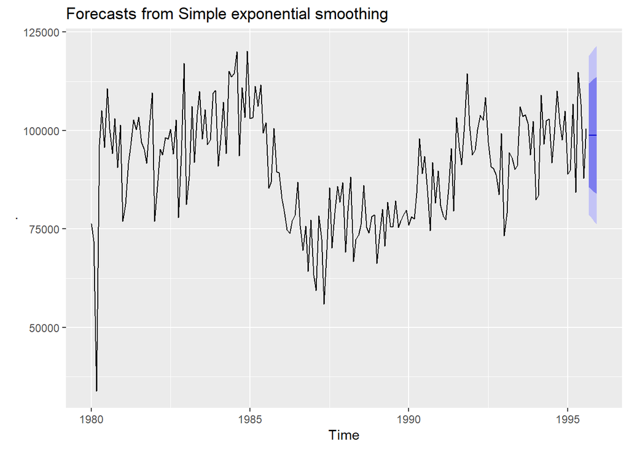

```r
# pigs_fcsumm %>% purrr::pluck('Smoothing parameters') %>% first()

# Chart forecasting next four months
pigs_fc %>%
  autoplot()
```

#### Given that we’re implementing simple exponential smoothing, values for the next four months are flat at approximately 98,816. Smoothing parameter $\alpha$ is .2971, and initial state $\ell_{0}$ is 77,260.

```r
# Call mean prediction of SES and compute upper and lower values of interval
pigs_fc_mean <- c((pigs_fc$mean[1] - sd(pigs_fc$residuals) * 1.96),
             (pigs_fc$mean[1] + sd(pigs_fc$residuals) * 1.96))

cat('\n SES low forecast = ', scales::comma(pigs_fc$lower[5]),
    '\n manual low forecast = ', scales::comma(pigs_fc_mean[1]),
    '\n',
    '\n SES high forecast = ', scales::comma(pigs_fc$upper[5]),
    '\n manual high forecast = ', scales::comma(pigs_fc_mean[2]))
```

```
##
##  SES low forecast =  78,612
##  manual low forecast =  78,680
##
##  SES high forecast =  119,021
##  manual high forecast =  118,953
```

#### The interval yielded by the `ses()` function is slightly wider than interval calculated manually; the lower value is smaller, and the upper value,larger.

### Exercise 7.2 & 7.3

#### Write your own function to implement simple exponential smoothing. The function should take arguments $y$ (the time series), alpha (the smoothing parameter $\alpha$) and l_0 (the initial level $\ell_{0}$). It should return the forecast of the next obvservation in the series. Does it give the same forecast as `ses()`?

#### Modify your function from the previous exerise to return the sum of squared errors rather than the forecast of the net observation. Then use the `optim()` function to find the optimal values of $\alpha$ and $\ell_{0}$. Do you get the same values as the `ses()`?

```r
# Complete the preceding exercise as building block, coding a custom function that takes y, a, and l_0 and returns a forecast for the next period, y_hat

# Define function
custom_ses_pred <- function(y, a, l0) {

  # If there's time, use trycatch() to confirm y is time series

  # Initalize y_hat as l_0
  y_hat <- l0

  # Loop over time series y, iterating value of y_hat
  for(j in 1:length(y)) {

    y_hat <- (a * y[j]) + ((1 - a) * y_hat)  # using component form

    }

  return(y_hat)

}

# Test custom function with alpha and l_0 values outputted by SES function
pigs_fc_a <- pigs_fc$model$par[['alpha']]
pigs_fc_l0 <- pigs_fc$model$par[['l']]
custom_ses_pred(y = pigs,
                a = pigs_fc_a,
                l0 = pigs_fc_l0) %>%
  invisible()
```

```r
# Code custom function that takes optimizes parameters alpha and l_0 based based on SSE
custom_ses_sse <- function(y, par = c(a, l0)) {

  # Initialize error and sum of squared errors at 0
  e <- 0
  sse <- 0

  # Initialize alpha and l_0 as custom function arguments a and l0
  a <- par[1]
  l0 <- par[2]

  # Initalize y_hat as l_0
  y_hat <- l0

  # Loop over time series y, accumulating and summing squared error
  for (i in 1:length(y)) {

    e <- y[i] - y_hat  # Calculate error between y and predicted y_hat
    sse <- e^2 + sse  # Accumulate squared error
    y_hat <- (a * y[i]) + ((1 - a) * y_hat)  # Predict next y_hat

    }

  return(sse)

}


# Use SSE to minimize
custom_ses_sse_min <- optim(y = pigs,
                              par = c(.5, pigs[1]),
                              fn = custom_ses_sse)

cat('\n SES alpha = ', custom_ses_sse_min$par[1],
'\n manual SSE-minimizing alpha = ', pigs_fc_a,
'\n',
'\n SES l_0 = ', custom_ses_sse_min$par[2],
'\n manual SSE-minimizing l_0 = ', pigs_fc_l0)
```

```
##
##  SES alpha =  0.2990081
##  manual SSE-minimizing alpha =  0.2971488
##
##  SES l_0 =  76379.27
##  manual SSE-minimizing l_0 =  77260.06
```